# Final Project - WQU Python II

Let's have a look at the QQ plots for the log of prices.

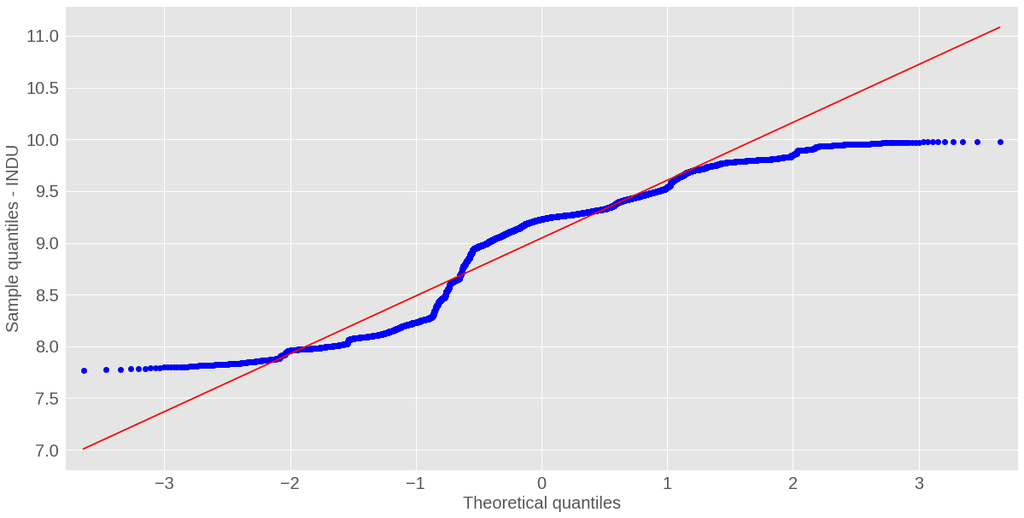

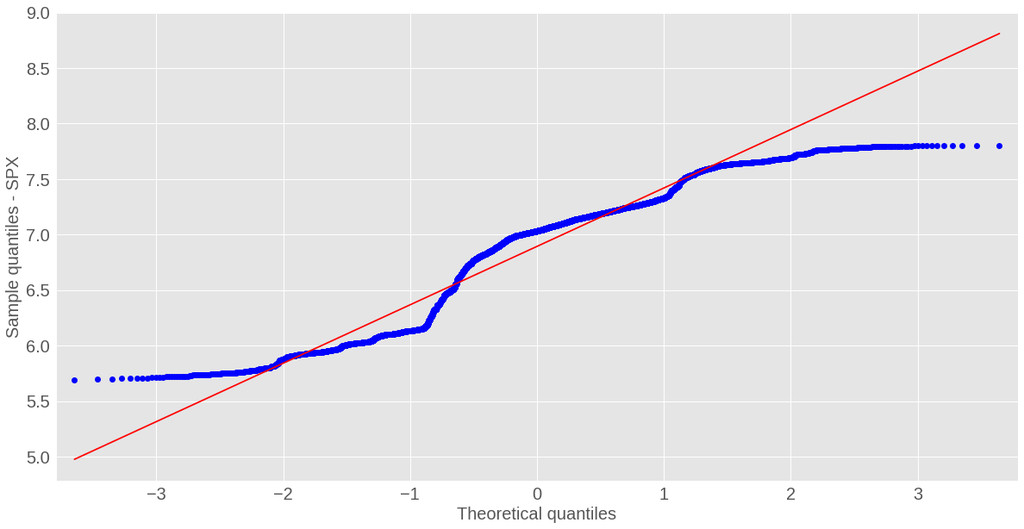

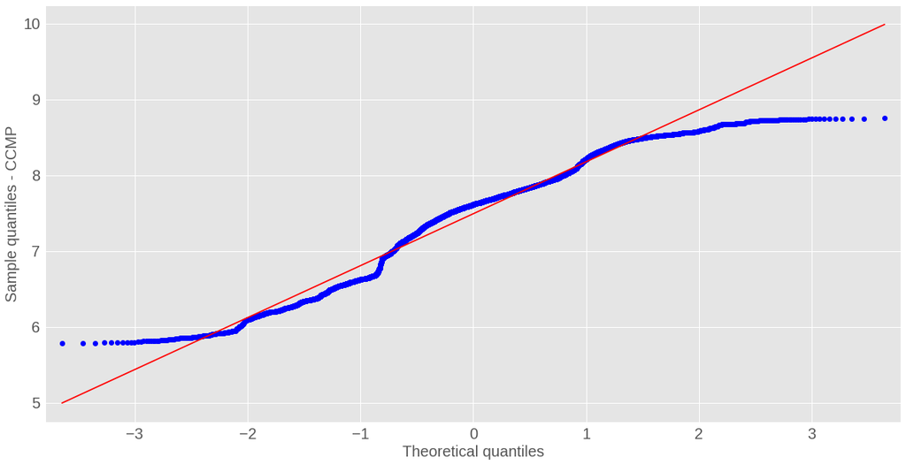

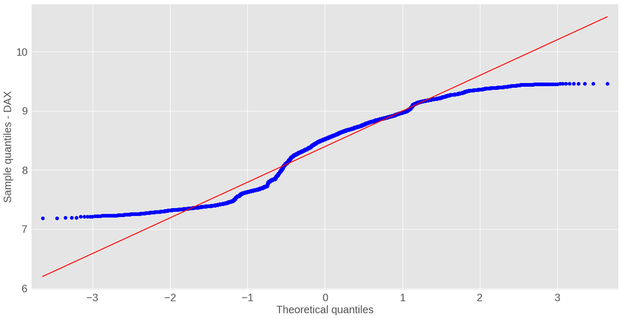

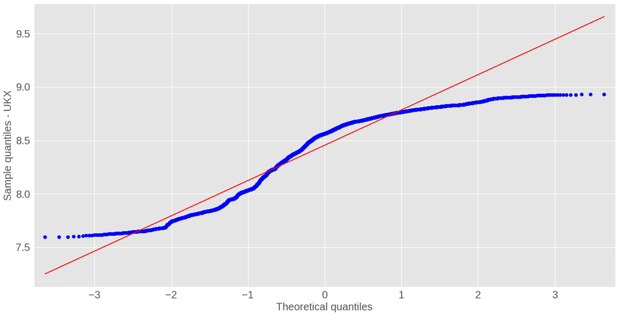

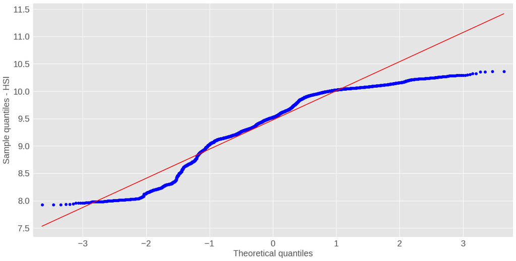

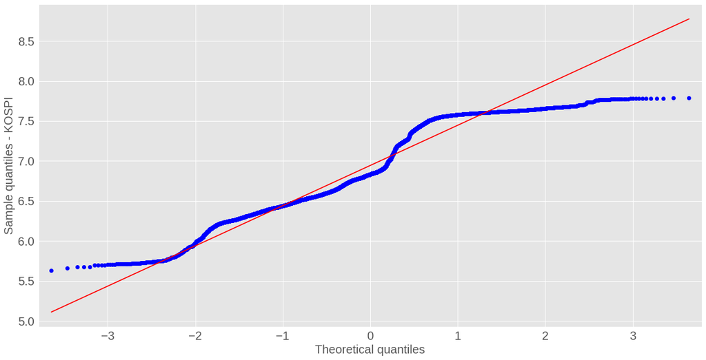

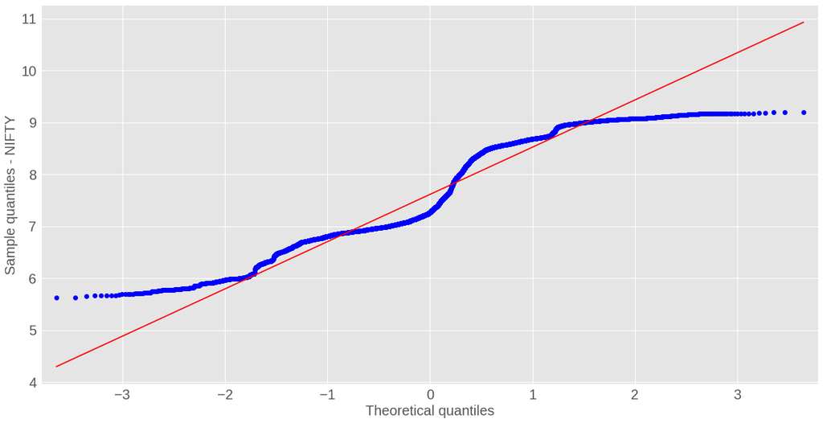

```python
    for i in range(0,len(log_data.columns)):
        qq_plot(log_data.iloc[:,i].values, log_data.columns[i])
```

This clearly shows that the logs of prices are not not normally distributed.

We can see in the below table as well. None of the logs of prices are normally distributed based on the normality tests as the p-values are zeros. The only exeption is KOSPI with no skew. This was also the case with the returns.

Again the amont of deviations from the normal distribution can be measured in terms of skewness and kurtosis from the below table.

```python
normality_tests_for_df(log_data).style.format("{:5.5f}")
```

|  | INDU | SPX | CCMP | DAX | UKX | HSI | KOSPI | NIFTY |
| --- | --- | --- | --- | --- | --- | --- | --- | --- |
| Skew | -0.64096 | -0.52952 | -0.41849 | -0.33209 | -0.77240 | -0.84387 | -0.03210 | 0.13525 |
| SkewTest_pValue | 0.00000 | 0.00000 | 0.00000 | 0.00000 | 0.00000 | 0.00000 | 0.25683 | 0.00000 |
| Kurt | -0.66887 | -0.72276 | -0.54378 | -1.00475 | -0.54790 | 0.21518 | -1.08751 | -1.22235 |
| KurtTest_pValue | 0.00000 | 0.00000 | 0.00000 | 0.00000 | 0.00000 | 0.00050 | 0.00000 | 0.00000 |
| NormTest_pValue | 0.00000 | 0.00000 | 0.00000 | 0.00000 | 0.00000 | 0.00000 | 0.00000 | 0.00000 |

## Extreme events - market crashes

I have assumed that the 20% market volatility was stated on annual basis. This implies about 1.26% daily volatility if the market runs 252 days.

I used normal PDF and CDF to calculate the probabilty of a retun of -22.61% (a loss). This loss happed during the day in 1987 market crash to DJIA.

The calculation results are below.

```python
print("\nProbability of extreme loss such as 1987 crash is (estimated daily vol 0.0126):")
print("%.20f" % (extreme_event_probability_pdf()/100))

print("\nProbability of extreme loss such as 1987 crash or a worse loss is (estimated daily vol 0.0126):")
print("%.20f" % (extreme_event_probability_cdf()))

print("\nProbability of -1% loss or a worse loss is (estimated daily vol 0.0126):")
print("%.20f" % (extreme_event_probability_cdf(-0.01)))
```

```
Probability of extreme loss such as 1987 crash is (estimated daily vol 0.0126):
0.00000000000000000000

Probability of extreme loss such as 1987 crash or a worse loss is (estimated daily vol 0.0126):
0.00000000000000000000

Probability of -1% loss or a worse loss is (estimated daily vol 0.0126):
0.21367765694890383799
```

The cumulative probabilities show the possibility of all worse events than the given loss. In our case the probability of the loss smaller than -22.61% given that the mean return is zero and the daily volatility is 1.26% is zero. This means that given our distribution function a loss of -22.61% is so unlikely that we can not even estimate the probability of this event because is so far from the mean that the estimated volatity can't even reach this point.

The problem is that the normal distirbution is not good at picking up the fat tails, the events far from the mean. This is not surprising. I looked at a possibility of the loss of -1%. In this case, we have some 21% chance of this event or a worse loss.

# Fractal Model of Market

Best reference I could find to the approach can be found here:

https://stackoverflow.com/questions/25067096/how-to-generate-a-fractal-graph-of-a-market-in-python

My implementation is baded directly on this example. Let us have look what can be done.

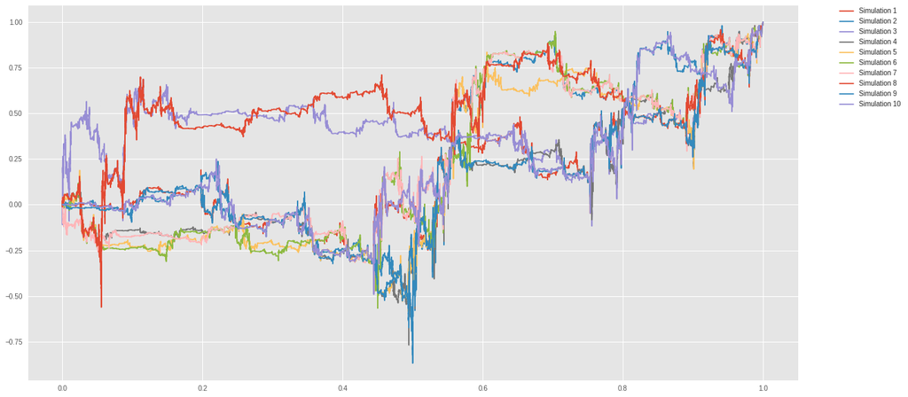

```python
from __future__ import division
plt.figure(figsize=(20,10))
for i in range(1,11):
    depth = 8
    graph = set()
    make_graph(depth, graph, (0, 0), (1, 1), [(1/9, 2/3), (5/9, 1/3)])
    plt.plot(*zip(*sorted(graph)), label='Simulation ' + str(i))
plt.legend(bbox_to_anchor=(1.05, 1), loc=2, borderaxespad=0.)
plt.show()
```

The way this model works is that the straight line between the start point $(t=0$ and $S=0)$ and end point $(t=1$ and $S=1)$ is broken down by a recusive algorithm that changes the size and the slope of the price increment $\Delta S$ and the size and of the time increment $\Delta t$. The time increment can not be negative. The straight line is broken down repeatedly. Then, it shufles the increments multiple time so it seems random. However, no stochastic differentials are involved in this process. Hence, we can see many similarities in the ten simulated lines above. They are made up of the name parts.

This is not a probabilitic process so we can only use this between two point. We could say estimate a fall in price, stable price and an increase in price as 3 different future points and run this algorithm to estimate the volatility of the market. It seems to model volatility clusters quite well. However, we would have to parametrise the algorithm to some data. Our case is just made up numbers.

Let us have a look how it looks when compared with real market data.

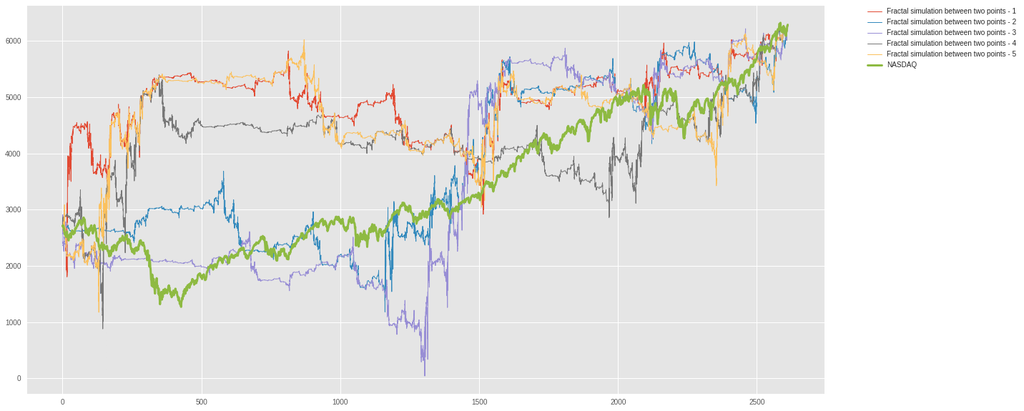

```python
from __future__ import division
# prepare the range of x (time periods)
x_fraclats = range(0, len(data.CCMP.loc['20070717':'20170714']))

# set up the start and end values
x_min = 0
y_min = data.CCMP.loc['20070717']

x_max = len(data.CCMP.loc['20070717':'20170714'])
y_max = data.CCMP.loc['20170714']

# create 5 fractal simulations and plot them with the actual data
plt.figure(figsize=(20,10))
for i in range(1,6):
    depth = 8
    graph = set()
    make_graph(depth, graph, (x_min, y_min), (x_max, y_max), [(1/9, 2/3), (5/9, 1/3)])
    plt.plot(*zip(*sorted(graph)), label='Fractal simulation between two points - ' +str(i),lw=1)
plt.plot(x_fraclats, data.CCMP.loc['20070717':'20170714'].values,label='NASDAQ', lw=3)
plt.legend(bbox_to_anchor=(1.05, 1), loc=2, borderaxespad=0.)
plt.show()
```

In the case of the algorithm I used, it is difficult to direct to volatility the same as as the market. We have the volatility clusters in the model however our estimated paths don't seem to dislpay much correlation with the actual path.

# Conclusion

We have done some Geometric Browning Motion and we have compared it to the real data. We can see that the Geometric Browning Motion is a nice model but it is not really addressing what the markets are like. We tried model the price path using fractal line decomposition however we are skeptical about this method.

If you have read until this point, well done!

# Functions

This section contains all functions.

## Brownian Motion

As shown in many text books, the browning moation is defined as:

# $$S_T = S_0e^{((r - \frac{1}{2}\sigma^2)T + \sigma \sqrt[]{T} z)}$$

$S_0$ ... current price/index level

$S_T$ ... price/index level in the future time $T$

$r$ ... constant riskless short rate

$\sigma$ ... constant volatility, defined as the standard deviation of log returns of $S$

$z$ ... Brownian motion, standard normally distributed random variable, stochastic term that is the direct result of the assumption

```python
def b_motion (S_0=0.0, r=0.0, sigma=0.0, T=0.0, M=0, I=0):
    """
    Generates Monte Carlo paths for geometric Brownian motion.

    Parameters
    ==========

    :param: S0 : float - initial stock/index value

    :param: r : float - constant short rate

    :param: sigma : float - constant volatility

    :param: T : float - final time horizon

    :param: M : int - number of time steps/intervals

    :param: I : int - number of paths to be simulated

    Returns
    =======
    paths : ndarray, shape (M + 1, I)
    simulated paths given the parameters
    """


    dt = float(T) / M
    paths = np.zeros((M + 1, I), np.float64)
    paths[0] = S_0
    for t in range(1, M + 1):
        rand = np.random.standard_normal(I)
        rand = (rand - rand.mean()) / rand.std()
        paths[t] = paths[t - 1] * np.exp((r - 0.5 * sigma ** 2) * dt +sigma * np.sqrt(dt) * rand)
    return paths
```

## Describe data

```python
def describe_array(array=np.array(0)):
    """
    Provides statistical descriptions for an numpy array

    Parameters
    ==========

    :param array: np.array() object with one row

    Returns
    =======

    :return: Print out the statistics
    """

    statistics = scs.describe(array)
    print("%14s %15s" % ('statistic', 'value'))
    print(30 * "-")
    print("%14s %15.0f" % ('size', statistics[0]))
    print("%14s %15.5f" % ('min', statistics[1][0]))
    print("%14s %15.5f" % ('max', statistics[1][1]))
    print("%14s %15.5f" % ('mean', statistics[2]))
    print("%14s %15.5f" % ('std', np.sqrt(statistics[3])))
    print("%14s %15.5f" % ('skew', statistics[4]))
    print("%14s %15.5f" % ('kurtosis', statistics[5]))

    return None
```

## Normality Tests for Numpy Array

```python
def normality_tests(array=np.array(0)):
    """
    Prints out the normality test for a numpy array with one row

    Parameters
    ==========

    :param array: np.array as one row

    Returns
    =======

    :return: Prints out the stats
    """

    print("%20s %25s" % ('Description', 'value/p-value'))
    print(50 * "-")
    print("%25s %15.5f" % ('Skew of data set', scs.skew(array)))
    print("%25s %15.5f" % ('Skew test p-value', scs.skewtest(array)[1]))
    print("%25s %15.5f" % ('Kurt of data set', scs.kurtosis(array)))
    print("%25s %15.5f" % ('Kurt test p-value', scs.kurtosistest(array)[1]))
    print("%25s %15.5f" % ('Norm test p-value', scs.normaltest(array)[1]))

    return None
```

## Plot cumulative returns

```python
def plot_cumulative_returns(df=pd.DataFrame()):
    """
    Pass in a dataframe of returns with Nan in the first row
    """
    df[:1] = 0
    with mpl.rc_context():
        mpl.rc("figure", figsize=(20,10))
        ax = ((df+1)).cumprod().plot(colormap='jet')
        ax.legend(fontsize=20)
    return None
```

## Normality Test for Dataframe

```python
def normality_tests_for_df(df=pd.DataFrame()):
    """
    Prepares the normality tests for any dataframe values
    Any p Value higher that 5% should be considered as a pass for the test

    :REMEMBER: It filters out any zeros from the data set.
    """

    # prepare and index for the return df
    index=['Skew',
           'SkewTest_pValue',
           'Kurt',
           'KurtTest_pValue',
           'NormTest_pValue']

    # prepare an array for value results
    test_value = np.zeros((5,df.shape[1]), np.float64)

    # calculate out the tests and statistics
    for i in range(0, df.shape[1]):
        # skewness
        test_value[0,i] = scs.skew(df.iloc[:,i].values[df.iloc[:,i].values!=0])
        # SkewTest_pValue
        test_value[1,i] = scs.skewtest(df.iloc[:,i].values[df.iloc[:,i].values!=0])[1]
        # Kurt
        test_value[2,i] = scs.kurtosis(df.iloc[:,i].values[df.iloc[:,i].values!=0])
        # KurtTest_pValue
        test_value[3,i] = scs.kurtosistest(df.iloc[:,i].values[df.iloc[:,i].values!=0])[1]
        # NormTest_pValue
        test_value[4,i] = scs.normaltest(df.iloc[:,i].values[df.iloc[:,i].values!=0])[1]

    return pd.DataFrame(test_value, index=index, columns=df.columns)
```

## QQ plot function

```python
def qq_plot(array=np.array(0), set_name='set_name'):
    """
    Prints QQ plot for a np.array object

    :REMEMBER: It filters out any zeros from the data set.
    """
    with mpl.rc_context():
        mpl.rc("figure", figsize=(20,10))
        sm.qqplot(array[array!=0].flatten(),line='s')
        plt.xlabel('Theoretical quantiles', fontsize=20)
        plt.ylabel('Sample quantiles - '+ set_name, fontsize=20)
```

## Plot price histogram and log price histogram

```python
def plot_hist_and_log_hist(array=np.array(0), set_name='set_name'):
    """
    Creates the price histogram and log of prices histogram

    Pass in an array with the prices
    """

    fig, axes = plt.subplots(nrows=1, ncols=2, figsize=(15, 7), sharex=False, sharey=False)
    ax0, ax1 = axes.flatten()

    shape, loc, scale = scs.lognorm.fit(array, floc=0)

    x = np.linspace(array.mean() - 3 * array.std(),
                        array.mean() + 3 * array.std())

    ax0.plot(x,
             scs.lognorm.pdf(x, shape, loc=loc, scale=scale),
             'b',
             lw=2.0,
             label='fitted_lognorm-3_deviations')

    ax0.plot(x,
             scs.norm.pdf(x, array.mean(), array.std()),
             'r',
             lw=2.0,
             label='fitted_normal-3_deviations')

    sns.distplot(array,
                  color='g',
                  kde_kws={"label": "Price kde - " + set_name},
                  hist_kws={"label": "Price hist - " + set_name},
                  bins=20,
                  ax=ax0)

    log_array = np.log(array)

    x = np.linspace(log_array.mean() - 3 * log_array.std(),
                        log_array.mean() + 3 * log_array.std())

    ax1.plot(x,
                 scs.norm.pdf(x, log_array.mean(), log_array.std()),
                 'r',
                 lw=2.0,
                 label='fitted_normal-3_deviations')

    sns.distplot(log_array,
                     color='m',
                     kde_kws={"label": "Log of Price kde - " + set_name},
                     hist_kws={"label": "Log of Price hist - " + set_name},
                     ax=ax1)

    plt.tight_layout()
    plt.show()

    return None
```

## Plot histogram

```python
def plot_hist(array=np.array(0), set_name='set_name'):
    """
    Plots the histogram for data - an array object.
    Normal distribution fit is add

    :REMEMBER: Assumes that if the data point is zero then there was no trading and so it is filtered out.
    """
    array = array[array!=0]

    with mpl.rc_context():
        mpl.rc("figure", figsize=(20,10))

        plt.figure()
        x = np.linspace(array.mean() - 3 * array.std(),
                            array.mean() + 3 * array.std())

        plt.plot(x,
                 scs.norm.pdf(x, array.mean(), array.std()),
                 'r',
                 lw=2.0,
                 label='fitted_normal-3_deviations')

        sns.distplot(array,
                      color='b',
                      kde_kws={"label": "Return kde - " + set_name},
                      hist_kws={"label": "Return hist - " + set_name})

        plt.draw()

    return None
```

## Extreme event probability - cdf

This is based on normal distribution so it rather should be called normal events

```python
def extreme_event_probability_cdf(event_value=-0.2261,mean=0.0,std_annual=0.2):
    """
    assumes volatility 0.2 annually
    assumes mean is zero for return series
    assumes event_value is -0.2261 based on 1987 one day return on DJIA index
    assumes 252 trading day in a year
    returns cumulative normal probability of event_value for the given mean and annual std
    """
    std_daily = std_annual/np.sqrt(252)
    return scs.norm.cdf(event_value,loc=mean, scale=std_daily)
```

## Extreme event probability - pdf

This is based on normal distribution so it rather should be called normal events.

```python
def extreme_event_probability_pdf(event_value=-0.2261,mean=0.0,std_annual=0.2):
    """
    assumes volatility 0.2 annually
    assumes mean is zero for return series
    assumes event_value is -0.2261 based on 1987 one day return on DJIA index
    assumes 252 trading day in a year
    returns normal probability of event_value for the given mean and annual std
    """
    std_daily = std_annual/np.sqrt(252)
    return scs.norm.pdf(event_value,loc=mean, scale=std_daily)
```

## Fractal Model of Market

```python
def make_graph(depth, graph, start, end, turns):
        """
        taken from https://stackoverflow.com/questions/25067096/how-to-generate-a-fractal-graph-of-a-market-in-python
        """
        #from __future__ import division # see the meaning here: https://www.python.org/dev/peps/pep-0238/
        from random import shuffle

        # add points to graph
        graph.add(start)
        graph.add(end)

        if depth > 0:
            # unpack input values
            fromtime, fromvalue = start
            totime, tovalue = end

            # calcualte differences between points
            diffs = []
            last_time, last_val = fromtime, fromvalue
            for t, v in turns:
                new_time = fromtime + (totime - fromtime) * t
                new_val = fromvalue + (tovalue - fromvalue) * v
                diffs.append((new_time - last_time, new_val - last_val))
                last_time, last_val = new_time, new_val

            # add 'brownian motion' by reordering the segments
            shuffle(diffs)

            # calculate actual intermediate points and recurse
            last = start
            for segment in diffs:
                p = last[0] + segment[0], last[1] + segment[1]
                make_graph(depth - 1, graph, last, p, turns)
                last = p
            make_graph(depth - 1, graph, last, end, turns)
        return None
```